# KNN_Erin_Kennedy

A00275664

2024-03-26

# Employing K-Nearest Neighbour for Obesity Prediction

# Introduction

## Preparation

Import the ObesityDataSet_raw_and_data_sinthetic dataset and install relevant packages using the **read.csv()** command

```r
obesity<-read.csv("~/A00275664/Data/ObesityDataSet_raw_and_data_sinthetic.csv",
                  header = T, sep = ",",
                  stringsAsFactors = FALSE)
```

```r
#Install relevant packages
library(tidyverse)
library(caret)
library(rpart)
library(dplyr)
library(gmodels)
library(class)
library(ggplot2)
```

## Analysis

### Initial Analysis

```r
#Rename columns for clarity
obesity <- obesity %>%
  rename("obesity_level" = "NObeyesdad",
         "high_cal_foods?" = "FAVC",
         "veg_meals" = "FCVC",
         "eat_between_meals" = "CAEC",
         "main_meals_count" = "NCP",
         "family_history" = "family_history_with_overweight")
unique(obesity$obesity_level) # the classifying variable
```

```
## [1] "Normal_Weight"       "Overweight_Level_I"  "Overweight_Level_II"
## [4] "Obesity_Type_I"      "Insufficient_Weight" "Obesity_Type_II"
## [7] "Obesity_Type_III"
```

[output not shown]

### Numeric Encoding of Categorical Variables

All categorical variables, except for the classifying variable, have been converted to numeric.

```r
# Change 'Gender' to numeric
obesity$Gender <- as.numeric(factor(obesity$Gender,
                                    levels = c("Female", "Male")))
# Change 'CALC' to numeric
obesity$CALC <- as.numeric(factor(obesity$CALC,
                                  levels = c("no", "Sometimes", "Frequently",
                                             "Always")))
# Change 'family_history' to numeric
obesity$family_history <- as.numeric(factor(obesity$family_history,
                                            levels = c("no", "yes")))
# Change 'high_cal_foods' to numeric
obesity$high_cal_foods <- as.numeric(factor(obesity$high_cal_foods,
                                            levels = c("no", "yes")))
# Change 'eat_between_meals' to numeric
obesity$eat_between_meals <- as.numeric(factor(obesity$eat_between_meals,
                                               levels = c("no", "Sometimes",
                                                          "Frequently",
                                                          "Always")))
# Change 'MTRANS' to numeric
obesity$MTRANS <- as.numeric(factor(obesity$MTRANS,
                                    levels = c("Public_Transportation",
                                               "Walking", "Automobile",
                                               "Motorbike", "Bike")))
# Change 'SCC' to numeric
obesity$SCC <- as.numeric(factor(obesity$SCC,
                                 levels = c("no", "yes")))
# Change 'SMOKE' to numeric
obesity$SMOKE <- as.numeric(factor(obesity$SMOKE,
                                   levels = c("no", "yes")))
```

```r
# Check conversion was successful
str(obesity)
```

[output not shown]

## Managing Null Values

### Identifying Missing Data

This dataset contains no missing values or symbols representing missing values

```r
null_values <- colSums(is.na(obesity)) # calculates count of null values in each column
print(null_values) # print amount of null values in each dataset
```

```
##            Gender               Age            Height            Weight
##                 0                 0                 0                 0
##    family_history   high_cal_foods?         veg_meals  main_meals_count
##                 0                 0                 0                 0
## eat_between_meals             SMOKE              CH2O               SCC
##                 0                 0                 0                 0
##               FAF               TUE              CALC            MTRANS
##                 0                 0                 0                 0
##     obesity_level    high_cal_foods
##                 0                 0
```

# K-NN Preparation

```r
table(obesity$obesity_level) # Frequency of the 7 obesity levels
summary(obesity[c("obesity_level", "Gender", "family_history")]) # example descriptive statistics
```

[output not shown]

First, normalisation is applied. Normalisation is essential in a machine learning algorithm, such as K-NN due to the reason that K-NN is dependent primarily on the distance between data points, to make predictions. Normalisation helps create a range applicable for all variables ensuring that each feature has a suitable proportional impact to the model’s distance calculations. This in turn reduces bias and can increase the accuracy rate of the model.

```r
# Percentage of each data value in classifying variable
round(prop.table(table(obesity$obesity_level)) * 100, digits = 1)
```

```
##
## Insufficient_Weight       Normal_Weight      Obesity_Type_I     Obesity_Type_II
##                12.9                13.6                16.6                14.1
##    Obesity_Type_III  Overweight_Level_I Overweight_Level_II
##                15.3                13.7                13.7
```

```r
# Columns before normalisation
summary(obesity[c("Height", "CH2O", "FAF")])
```

```
##      Height           CH2O            FAF
##  Min.   :1.450   Min.   :1.000   Min.   :0.0000
##  1st Qu.:1.630   1st Qu.:1.585   1st Qu.:0.1245
##  Median :1.700   Median :2.000   Median :1.0000
##  Mean   :1.702   Mean   :2.008   Mean   :1.0103
##  3rd Qu.:1.768   3rd Qu.:2.477   3rd Qu.:1.6667
##  Max.   :1.980   Max.   :3.000   Max.   :3.0000
```

Each have a different ranges which can affect the impact on the model’s distance calculations

## Normalisation

```r
# Function to normalise data
normalise <- function(x) {
  return ((x - min(x)) / (max(x) - min(x)))
}
# Specify the columns to normalise
columns_normalise <- c("Age", "Weight", "main_meals_count", "Height", "veg_meals", "CH2O", "FAF", "TUE")

# Apply the normalise function to the specified columns using lapply
obesity_normalise <- as.data.frame(lapply(obesity[columns_normalise], normalise)) #Normalised dataframe
# Check if data has been normalised, min should = 0 and max should = 1
summary(obesity_normalise$Height)
```

```
##    Min. 1st Qu.  Median    Mean 3rd Qu.    Max.
##  0.0000  0.3396  0.4726  0.4749  0.6009  1.0000
```

This code divides **obesity_normalise** into two parts: one for training a machine learning model and another for testing its performance. It starts by setting a seed to ensure consistent randomness. Then, it shuffles the rows of the dataset to mix up the data. This is neccessary due to the reason that the **obesity_level** column is quite ordered, sometimes seeing hundreds of the same level at once.

Afterwards, the shuffled rows are split accordingly into training and testing sets. The labels associated with these rows are then extracted from the original dataset (“obesity”) and paired with the corresponding training and testing data. This ensures that the labels are correctly assigned to both sets of data for training and evaluation purposes.

```r
# Split data randomly into training (80%) and testing (20%) sets
set.seed(123)
# returns number of rows in obesity
total_samples <- nrow(obesity_normalise)
# selects a random sample
shuffled_rows <- sample(total_samples)
# 80% for training, 20% for testing
train_prop <- 0.8
# retrieves approximately 80% of total samples
n_train <- round(train_prop * total_samples)
# training set is set from 1-n_train
train_rows <- shuffled_rows[1:n_train]
#test set is n_train+1 - the rest of samples
test_rows <- shuffled_rows[(n_train + 1):total_samples]
# contains the training attributes
obesity_train <- obesity_normalise[train_rows, ]
#contains the test attributes
obesity_test <- obesity_normalise[test_rows, ]
# contains the corresponding training labels
obesity_train_labels <- obesity[train_rows, "obesity_level"]
# contains the corresponding test labels
obesity_test_labels <- obesity[test_rows, "obesity_level"]
```

Next, check the r-code has run successfully and the seven levels are proportioned adequately for the K-NN model to learn from and test predictions with.

```r
# Check training and test labels are correctly proportioned
table(obesity_train_labels)
table (obesity_test_labels)
```

[output not shown]

# Train K-NN Model

## Attempt 1

### Normalisation: k=42

```r
test_predictions <- knn(train = obesity_train, test = obesity_test,
                      cl = obesity_train_labels, k = 42)
```

A contingency table is then generated, using the *gmodels* package, comparing actual labels (obesity_test_labels) with predicted labels (test_predictions). The contingency table is printed, showing the counts of correct and incorrect predictions, along with row and column totals.

```r
# Creating a contingency table with row and column totals
Crosstable_normalise <- CrossTable(x = obesity_test_labels,
                                   y = test_predictions, prop.chisq = FALSE)
# Print the table
print(Crosstable_normalise, digits = 2) # 61.6% accuracy rate
```

[output not shown]

With a k value of 42, the reported accuracy rate is 61.6%, indicating the proportion of correctly classified instances. This can be improved upon.

# Improve Model Performance

## Attempt 2

### Normalisation: k= 5

Here, different *k* values are attempted. Its important to note that lower *k* values can lead to an overfit model which can result in low specificity and low bias

```r
test_predictions <- knn(train = obesity_train,
                        test = obesity_test,
                        cl = obesity_train_labels,
                        k = 5)
Crosstable_normalise <- CrossTable(x = obesity_test_labels,
                                   y = test_predictions,
                                   prop.chisq = FALSE)
print(Crosstable_normalise, digits = 2) # 73% accuracy rate
```

[output not shown]

## Attempt 3

### Normalisation: k= 3,

We see here reducing the *k* value of a normalised dataset improves our accuracy rate to at most 77.3%. Another method to try enhance this accuracy rate is Z-Score Standardisation.

```r
test_predictions <- knn(train = obesity_train, test = obesity_test,
                        cl = obesity_train_labels, k = 3)
Crosstable_normalise <- CrossTable(x = obesity_test_labels, y = test_predictions, prop.chisq = FALSE)
print(Crosstable_normalise, digits = 2) # 77.3% accuracy rate
```

[output not shown]

# Improving K-NN Model With Z-Score Standardisation

Earlier, normalisation was performed as a processing technique for K-NN, whilst in this instance standardisation is occurring. Both techniques are have similiar features but vary slightly.

Normalisation rescales the values of each feature to fall within a specific range, often between 0 and 1. On the other hand, standardisation transforms the values of each feature to have a mean of zero and a standard deviation of one, achieved by subtracting the mean and dividing by the standard deviation.

Whilst normalisation ensures that features are on a consistent scale, standardisation makes features comparable by removing the effect of scale differences.

```r
columns_scale <- c("Age", "Weight", "main_meals_count",
                   "Height", "veg_meals", "CH2O",
                   "FAF", "TUE")
obesity_zscore <- obesity
# standardise columns
obesity_zscore[columns_scale] <- scale(obesity_zscore[columns_scale])
# Check code has run successfully
summary(obesity_zscore$Height) # Check mean of the standardised variable is zero
```

```
##     Min.  1st Qu.   Median     Mean  3rd Qu.     Max.
## -2.69737 -0.76821 -0.01263  0.00000  0.71579  2.98294
```

Data is again split randomly 80:20 into a training and test set.

```r
# Split data randomly into training (80%) and testing (20%) sets
set.seed(123)
# returns number of rows in obesity
total_samples <- nrow(obesity_normalise)
# selects a random sample
shuffled_rows <- sample(total_samples)
# 80% for training, 20% for testing
train_prop <- 0.8
# retrieves approximately 80% of total samples
n_train <- round(train_prop * total_samples)
# training set is set from 1-n_train
train_rows <- shuffled_rows[1:n_train]
#test set is n_train+1 - the rest of samples
test_rows <- shuffled_rows[(n_train + 1):total_samples]
# contains the training attributes
obesity_train <- obesity_normalise[train_rows, ]
#contains the test attributes
obesity_test <- obesity_normalise[test_rows, ]
# contains the corresponding training labels
obesity_train_labels <- obesity[train_rows, "obesity_level"]
# contains the corresponding test labels
obesity_test_labels <- obesity[test_rows, "obesity_level"]
```

Data processing and checks are completed to ensure even distributions

```r
# check distributions and labels are adequately proportioned
table(obesity_test_labels)
table(obesity_train_labels)
```

[output not shown]

# Re-run K-NN Classification

## Attempt 1

```r
test_predictions_zscore <- knn(train = obesity_train,
                               test = obesity_test,
                               cl = obesity_train_labels,
                               k = 42)
Crosstable_zscore<-CrossTable(x = obesity_test_labels,
                              y = test_predictions_zscore,
                              prop.chisq = FALSE)
print(Crosstable_zscore, digits=2) # 62.08 accuracy rate
```

[output not shown]

## Attempt 2

```r
test_predictions_zscore <- knn(train = obesity_train, test = obesity_test,
                               cl = obesity_train_labels, k = 5)
Crosstable_zscore<-CrossTable(x = obesity_test_labels, y = test_predictions_zscore,
                         prop.chisq = FALSE)
print(Crosstable_zscore, digits=2) # 73.5%
```

[output not shown]

## Attempt 3

```r
test_predictions_zscore <- knn(train = obesity_train,
                               test = obesity_test,
                               cl = obesity_train_labels,
                               k = 3)
Crosstable_zscore<-CrossTable(x = obesity_test_labels,
                              y = test_predictions_zscore,
                              prop.chisq = FALSE)
print(Crosstable_zscore, digits=2) # 75.5% accuracy rate
```

[output not shown]

Lastly, a scatterplot is created to clearly show predictions made using the K-NN model and actual results from the data. Each point represents a pair of actual and predicted labels.

If the model makes perfect predictions, all points would fall along a dashed red line. However, deviations from this line indicate where the model’s predictions differ from the actual labels.

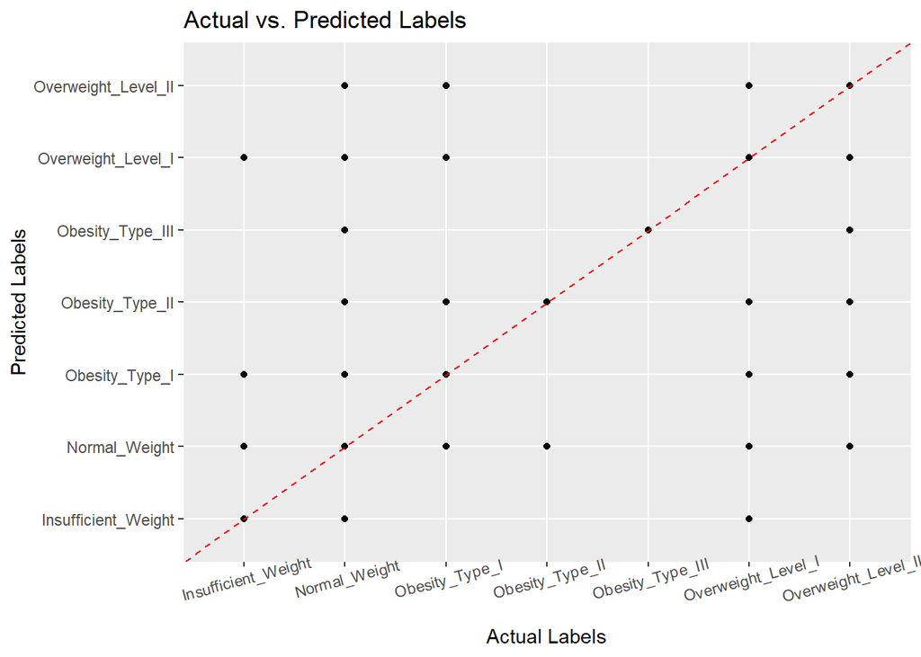

```r
# Create a dataframe containing actual and predicted labels
obesity_results <- data.frame(Actual = obesity_test_labels, Predicted = test_predictions)

# Plot actual vs. predicted labels
ggplot(obesity_results, aes(x = Actual, y = Predicted)) + #label x and y axis
  geom_point() +
  geom_abline(intercept = 0, slope = 1, # insert red, dashed line
              colour = "red", linetype = "dashed") +
  labs(x = "Actual Labels", y = "Predicted Labels", # x and y axis titles
       title = "Actual vs. Predicted Labels") + # title of graph
  theme(axis.text.x = element_text(angle = 15))  # Rotate x-axis labels by 45 degrees
```

## Conclusion

This analysis investigated the application of the K-Nearest Neighbors (K-NN) algorithm to predict obesity levels in a given dataset. One initial challenge involved handling variables with different measurement scales. Lantz’s book proved to be a valuable resource in addressing this issue ((Lantz 2013)).

The exploration involved multiple iterations and refinements to optimise model performance. This included adjusting parameters like the “k” value (number of neighbors considered) and applying different pre-processing techniques.

Data preparation began with encoding categorical variables and normalising the data to ensure consistency across features. The dataset was then split into training and testing sets for model evaluation.

While the graphical results suggest some learning by the model, with clusters forming along the “correct” prediction line, there are also some outliers. For instance, the model might predict “Normal Weight” as “Overweight Level II”.

Introducing a larger and more diverse dataset with a wider distribution of weight levels could potentially improve the model’s accuracy and effectiveness. This would provide the model with a broader range of examples to learn from and potentially enhance its ability to make more accurate predictions.

## References

“Rmarkdown.pdf” (n.d.) Lantz (2013) “What Is the k-Nearest Neighbors Algorithm? | IBM” (n.d.) Sharma (2019) “How KNN Uses Distance Measures? - Analytics Vidhya” (n.d.) “Intro to Machine Learning in R (K Nearest Neighbours Algorithm)” (n.d.) “Knn” (n.d.)

“How KNN Uses Distance Measures? - Analytics Vidhya.” n.d. Accessed April 4, 2024. https://www.analyticsvidhya.com/blog/2021/08/how-knn-uses-distance-measures/.

“Intro to Machine Learning in R (K Nearest Neighbours Algorithm).” n.d. Accessed April 4, 2024. https://ourcodingclub.github.io/tutorials/machine-learning/.

“Knn.” n.d. Accessed April 4, 2024. https://plotly.com/r/knn-classification/.

Lantz, Brett. 2013. *Machine Learning with R. [Electronic Resource]*. Packt Publishing.

“Rmarkdown.pdf.” n.d. Accessed April 3, 2024. https://raw.githubusercontent.com/rstudio/cheatsheets/main/rmarkdown.pdf.

Sharma, Pulkit. 2019. “Why Is Scaling Required in KNN and K-Means?” *Analytics Vidhya* (blog). August 25, 2019. https://medium.com/analytics-vidhya/why-is-scaling-required-in-knn-and-k-means-8129e4d88ed7.

“What Is the k-Nearest Neighbors Algorithm? | IBM.” n.d. Accessed April 4, 2024. https://www.ibm.com/topics/knn.